# Chocolate bar ratings analysis

Contributors: Bailey Lei, George J. J. Wu

Date: November, 2018

Chocolate bar is one of the most popular treats around the world, but not all chocolate bars are made the same. Some chocolate bars are made with a high concentration of cocoa beans and are thus considered more dark, while some chocolate bars are far less concentrated in terms of cocoa and are thus considered more light.

This begs a question - are darker chocolate bars simply better? For instance, in the eyes of the experts, are chocolate bars with 99% cocoa concentration simply better than chocolate bars with only 70% cocoa concentration?

This analysis would explore the relationship between chocolate darkness (cocoa percentage) and chocolate expert ratings.

### Data set

We examined the expert ratings of 1,795 chocolate bars compiled by Brady Brelinski, a Founding Member of the [Manhattan Chooclate Society](http://flavorsofcacao.com/index.html). A detailed description of the data set can be found on [Kaggle](https://www.kaggle.com/rtatman/chocolate-bar-ratings). We were particularly interested in two variables in the data - chocolate darkness (cocoa percentage) and expert ratings.

We began our analysis by examining each variable individually.

### Chocolate darkness

First, we examined the chocolate darkness variable visually.

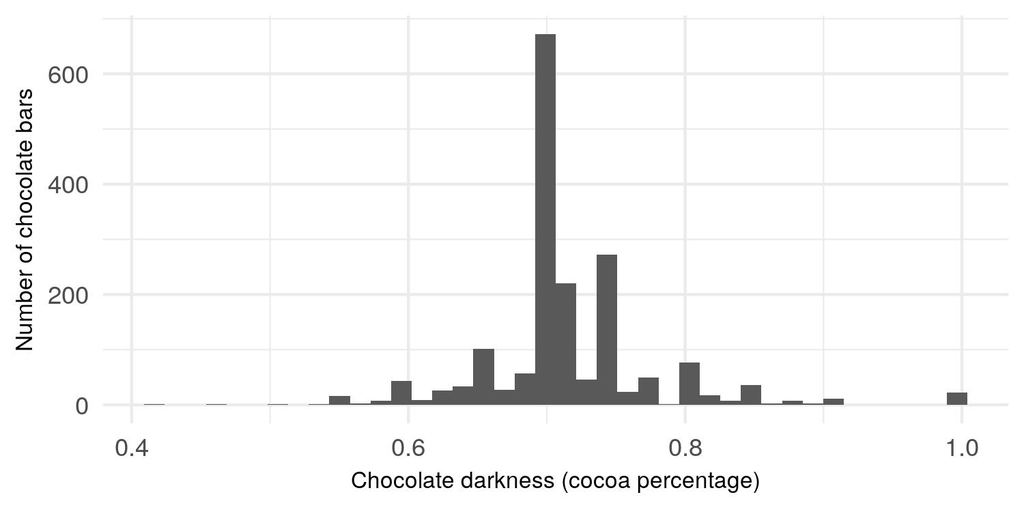

*Figure 1.* Chocolate darkness distribution for 1,795 chocolate bars. Chocolate darkness was measured by cocoa concentration percentage in a chocolate bar. Measurements were compiled by the Manhattan Chocolate Society.

We also examined chocolate darkness numerically.

*Table 1.* Descriptive statistics of chocolate darkness. Chocolate darkness was measured by cocoa concentration percentage in a chocolate bar. The minimum darkness, darkness at the 25% quantile, median darkness, mean darkness, darkness at the 75% quantile, as well as the maximum darkness of 1,795 chocolate bars were reported.

| minimum | q1 | median | mean | q3 | maximum |
| --- | --- | --- | --- | --- | --- |
| 0.42 | 0.7 | 0.7 | 0.7169833 | 0.75 | 1 |

Both visual and numerical examinations revealed that the vast majority of chocolate bars in the data set had a cocoa concentration of about 70%. The most concentrated chocolate bars in the data set attained 100% cocoa purity, whereas the least concentrated chocolate bars had a cocoa percentage of only 42%. The distribution of chocolate darkness is somewhat normal.

### Chocolate expert ratings

Next, we examined chocolate expert ratings visually.

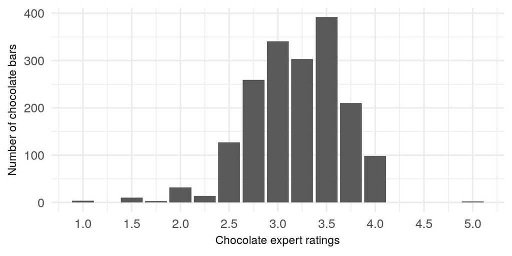

*Figure 2.* Expert ratings distribution for 1,795 chocolate bars. Each chocolate bar was rated by experts using a Likert scale system, with 1 being unpleasant, 2 being disappointing, 3 being satisfactory, 4 being premium, and 5 being elite. Expert ratings were compiled by the Manhattan Chocolate Society.

We also examined chocolate expert ratings numerically.

*Table 2.* Descriptive statistics of chocolate expert ratings. Ratings were generated by chocolate experts using a Likert scale system. The minimum rating, rating at the 25% quantile, median rating, mean rating, rating at the 75% quantile, as well as the maximum rating of 1,795 chocolate bars were reported.

| minimum | q1 | median | mean | q3 | maximum |
| --- | --- | --- | --- | --- | --- |
| 1 | 2.875 | 3.25 | 3.185933 | 3.5 | 5 |

Each chocolate bar was rated by experts using a [Likert scale](https://en.wikipedia.org/wiki/Likert_scale). Some of the main encodings were: 1 is unpleasant, 2 is disappointing, 3 is satisfactory (3.75 is praiseworthy), 4 is premium, and 5 is elite. A more detailed description of the rating system can be found on [Kaggle](https://www.kaggle.com/rtatman/chocolate-bar-ratings/home).

Most chocolate bars in the data set were given a rating of around 3 to 3.5, with 1 being the lowest rating given, and 5 being the highest rating given. The distribution of chocolate expert ratings seemed to be slightly left-skewed.

### Chocolate darkness and expert ratings

Let’s explore the relationship between chocolate darkness and expert ratings. Expert ratings is an ordinal variable with more than five categories. For this reason, we would first treat expert ratings simply as a continuous variable, followed by an analysis in which it would also be treated as a categorical variable.

#### Expert ratings as a continuous variable

For this part of our analysis, we would explore the relationship between chocolate darkness and expert ratings, under the assumption that their relationship to be linear, and that expert ratings to be a continuous variable.

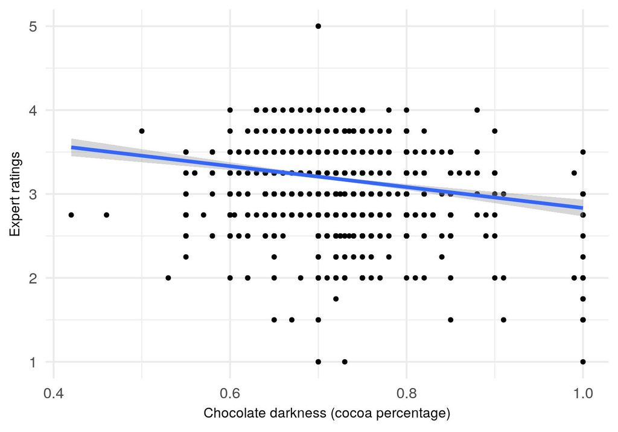

*Figure 3.* Relationship between chocolate darkness and expert ratings for 1,795 chocolate bars. Grey section represents 95% confidence intervals for the line of best fit (blue line), generated using linear regression.

We also computed the [Pearson’s correlation coefficient](https://en.wikipedia.org/wiki/Pearson_correlation_coefficient) and its p-value between the two variables.

*Table 3.* Correlation between chocolate darkness and expert ratings for 1,795 chocolate bars. Note that `estimate` refers to the correlation coefficient that was calculated using Pearson’s product-moment correlation method. This coefficient was significantly different from 0 as determined by a t-test (t = -7.07589) with 1793 degrees of freedom at 95% level of confidence.

| estimate | statistic | p.value | parameter | conf.low | conf.high | method | alternative |
| --- | --- | --- | --- | --- | --- | --- | --- |
| -0.1648202 | -7.07589 | 0 | 1793 | -0.2094894 | -0.1194644 | Pearson’s product-moment correlation | two.sided |

#### Expert ratings as a categorical variable

We would next treat chocolate expert ratings as a categorical variable. To simplify comparisons, this analysis further categorized chocolate bars that were less than or merely satisfactory (with 3 or lower ratings) as `low quality` chocolate (n = 790), and chocolate bars that were beyond satisfactory (with greater than 3 ratings) as `high quality` chocolate (n = 1005). We chose 3.0 ratings as the splitting threshold in the hope that both low and high quality groups contained very roughly the same amount of chocolate bars.

We then compared the mean chocolate darkness (cocoa percentage) between the two expert ratings or quality groups.

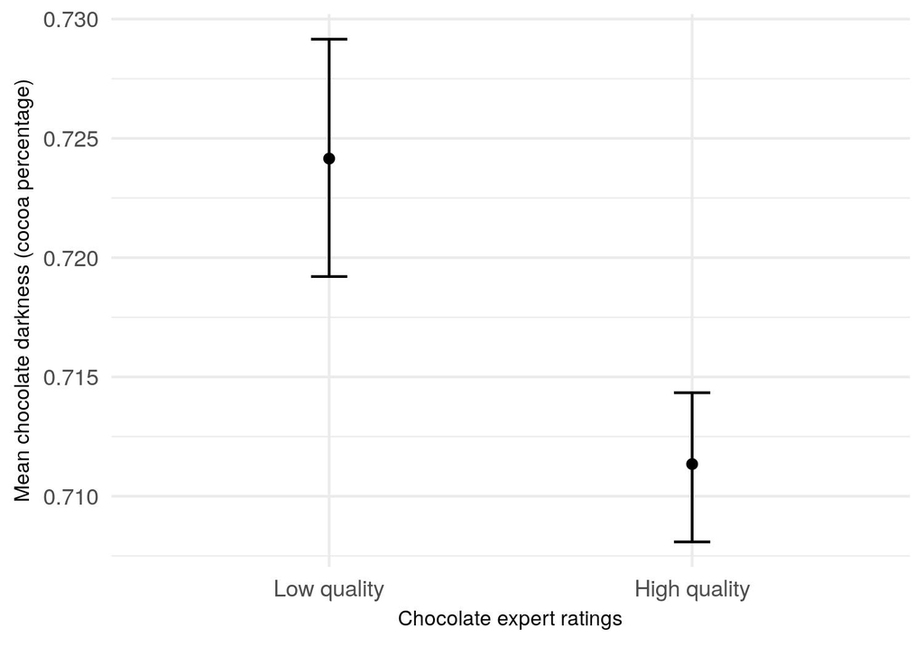

*Figure 4.* Mean chocolate darkness (cocoa percentage) for low quality (n = 790) chocolate and high quality (n = 1005) chocolate. Chocolate bars with 3 or lower ratings were considered as low quality, and chocolate bars with greater than 3 ratings were considered as high quality. Error bars represent 95% confidence intervals for each mean estimate.

As suggested by `Figure 4.`, high quality chocolate bars seemed to have lower cocoa concentration. Let’s formally test this observation by conducting a [Welch’s t-test](https://en.wikipedia.org/wiki/Welch%27s_t-test). We chose to use a Welch’s t-test because the two chocolate quality groups differed in sample size, and we assumed that the variance of the two quality groups to be different.

We would be testing the following null and alternative hypothesis:

H0: The mean chocolate darkness (cocoa percentage) of the high quality chocolate is *no different* than that of the low quality chocolate.

HA: The mean chocolate darkness (cocoa percentage) of the high quality chocolate is *different* than that of the low quality chocolate.

*Table 4.* Results of Welch’s two-sided t-test comparing low quality (n = 790) and high quality (n = 1005) chocolates in terms of mean chocolate darkness (cocoa percentage). Note that `statistic` refers to the t-test statistic, and was associated with 1288 degrees of freedom.

| statistic | p.value | parameter | conf.low | conf.high | method | alternative |
| --- | --- | --- | --- | --- | --- | --- |
| -4.075533 | 4.87e-05 | 1288.021 | -0.0189668 | -0.0066405 | Welch Two Sample t-test | two.sided |

As indicated by `Table 4.`, there was enough evidence to reject the null hypothesis. There was a statistically significant difference in the mean cocoa percentage for low quality (M = 0.7242, SD = 0.0765) chocolate bars and high quality (M = 0.711, SD = 0.0497) chocolate bars; t(1288) = -4.0755, p < 0.0001. Nonetheless, note that this difference in mean chocolate darkness between the two quality groups was practically trivial - only about 1.2%.

### Summary

We observed that chocolate experts tend to give somewhat lower ratings as chocolate becomes more dark, although this tendency is very weak. We also observed that the mean chocolate darkness difference between low and high quality chocolate bars was trivial. Both observations suggest that darker chocolate bars are not necessarily better chocolate bars. There seems to be no clear relationship between chocolate darkness and expert ratings.

### Limitations and future directions

There were a number of limitations with the current analysis.

For instance, note that most chocolate bars in our data set were already relatively dark - around 70% cocoa concentration. To capture a more comprehensive picture of the relationship between chocolate darkness and ratings, we can gather additional chocolate bar samples that are much less concentrated in future analyses.

Furthermore, we have not yet considered the scenarios in which the relationship between chocolate darkness and ratings could be non-linear. For instance, maybe experts prefer chocolate that is not too dark, or not too light, but with just the right amount of cocoa.

In future analyses, we can explore these scenarios in the future by computing [Kendall’s tau](https://en.wikipedia.org/wiki/Kendall_rank_correlation_coefficient) correlation coefficient instead, or by fitting a smooth line over our scatter plot using [LOESS](https://en.wikipedia.org/wiki/Local_regression) instead.

We also did not consider other factors that can influence the ratings of the chocolate bars, such as the origin and quality of the cocoa beans, as well as the company that produced the chocolate bars.

In future analyses, we can introduce additional variables such as cocoa bean origin, cocoa bean type, as well as name of the chocolate company. We can then use supervised machine learning algorithms, such as the decision tree algorithm, to help us determine which are the strongest predictors for high chocolate expert ratings.

### References

Tatman, R. (2017). Chocolate bar ratings. Retrieved from https://www.kaggle.com/rtatman/chocolate-bar-ratings/home

Pemberton, C. (2018). Cacao versus cocoa: Are you eating real chocolate? Retrieved from https://blog.paleohacks.com/cacao-vs-cocoa/#

Grace-Martin, K. (2018). Can Likert scale data ever be continuous? Retrieved from https://www.theanalysisfactor.com/can-likert-scale-data-ever-be-continuous